# REAL TIME DATA ANALYTICS

## REAL TIME DATA ANALYTICS PROJECT

```
                     BY

          PRASHANT PATEL (201B190)
          SHREY PANDEY (201B258)
          TANYA ISSARANI (201B287)
```

[figure not shown]

img courtsey - https://unsplash.com/@jonflobrant

*The aim of this project is just to explore the dataset and generate insights from it.*

Here is the description of all the variables / features available in the dataset which will help us to perform EDA:

1. id - a unique identifier for each trip
2. vendor_id - a code indicating the provider associated with the trip record
3. pickup_datetime - date and time when the meter was engaged
4. dropoff_datetime - date and time when the meter was disengaged
5. passenger_count - the number of passengers in the vehicle (driver entered value)
6. pickup_longitude - the longitude where the meter was engaged
7. pickup_latitude - the latitude where the meter was engaged
8. dropoff_longitude - the longitude where the meter was disengaged
9. dropoff_latitude - the latitude where the meter was disengaged
10. store_and_fwd_flag - This flag indicates whether the trip record was held in vehicle memory before sending to the vendor because the vehicle did not have a connection to the server (Y=store and forward; N=not a store and forward trip)
11. trip_duration - (target) duration of the trip in seconds

```python
#Importing Necessary Libraries

import pandas as pd
import numpy as np
import matplotlib.pyplot as plt
%matplotlib inline
import seaborn as sns
import datetime
```

```python
#Reading csv file

df = pd.read_csv('/Users/rishabh/Downloads/nyc_taxi_trip_duration.csv')
```

```python
#Visualising data's metadata

df.info()
```

```
<class 'pandas.core.frame.DataFrame'>
RangeIndex: 729322 entries, 0 to 729321
Data columns (total 11 columns):
 #   Column              Non-Null Count   Dtype
---  ------              --------------   -----
 0   id                  729322 non-null  object
 1   vendor_id           729322 non-null  int64
 2   pickup_datetime     729322 non-null  object
 3   dropoff_datetime    729322 non-null  object
 4   passenger_count     729322 non-null  int64
 5   pickup_longitude    729322 non-null  float64
 6   pickup_latitude     729322 non-null  float64
 7   dropoff_longitude   729322 non-null  float64
 8   dropoff_latitude    729322 non-null  float64
 9   store_and_fwd_flag  729322 non-null  object
 10  trip_duration       729322 non-null  int64
dtypes: float64(4), int64(3), object(4)
memory usage: 61.2+ MB
```

```python
# Checking intial 5 rows

df.head()
```

|  | id | vendor_id | pickup_datetime | dropoff_datetime | passenger_count | pickup_longitude | pickup_latitude | dropoff_longitude | dropoff_latitude | store_and_fwd_flag | trip_duration |
| --- | --- | --- | --- | --- | --- | --- | --- | --- | --- | --- | --- |
| 0 | id1080784 | 2 | 2016-02-29 16:40:21 | 2016-02-29 16:47:01 | 1 | -73.953918 | 40.778873 | -73.963875 | 40.771164 | N | 400 |
| 1 | id0889885 | 1 | 2016-03-11 23:35:37 | 2016-03-11 23:53:57 | 2 | -73.988312 | 40.731743 | -73.994751 | 40.694931 | N | 1100 |
| 2 | id0857912 | 2 | 2016-02-21 17:59:33 | 2016-02-21 18:26:48 | 2 | -73.997314 | 40.721458 | -73.948029 | 40.774918 | N | 1635 |
| 3 | id3744273 | 2 | 2016-01-05 09:44:31 | 2016-01-05 10:03:32 | 6 | -73.961670 | 40.759720 | -73.956779 | 40.780628 | N | 1141 |
| 4 | id0232939 | 1 | 2016-02-17 06:42:23 | 2016-02-17 06:56:31 | 1 | -74.017120 | 40.708469 | -73.988182 | 40.740631 | N | 848 |

# Observations before Univariate:

*Time*

---Datetime format needs to be changed from Object to datetime---

Date gives information about Day, Month & Year.

Time stamp gives information about Time of the day.

Hypothesis w.r.t. time:

1. Which days of the weeks do we see more rush?
2. Which are heavy demanding seasons/months of the year?
3. Which time of the day viz.Morning, afternoon or Evening see higher ridership?

*distance*

---Latitudes and Longitudes are geolocation coordinates, we're okay with them being float---

PickUps and DrOpOffs gives us information about city's demand areas.

Hypothesis w.r.t. Lats and Longs:

1. Do passengers prefer shorter or longer rides?
2. Which Coordinates or geolocations have high demands?

*vendor_id*

---vendor_id, need to be converted to category---

VendorId gives us information about the assigned vendor for each ride.

Hypothesis w.r.t. VendorID:

1. Which Vendor gets maximum number of rides?

*passenger_count*

---passenger_count, it has to be int---

passenger_count tells us number of passenger per rides as input by driver.

Hypothesis w.r.t. passenger_count:

1. Do people travel more in groups or solo?
2. In how many trips were there optimum number of people in the cab?

*store_and_fwd_flag*

---store_and_fwd_flag, need to convert into category---

store_and_fwd_flag tells us whether cab was connected to server the whole time.

Hypothesis w.r.t. store_and_fwd_flag:

1. In how many instances was cab not connected to the server?

*trip_duration*

---trip_duration, not to be converted---

trip_duration tells the time in seconds for each trip.

Hypothesis w.r.t. trip_duration :

1. Distribution of trip_duration across all trips?
2. Has some trip been unneccesarily longer?

*misc*

1. Need to convert store_and_fwd_flag, vendor_id, to category.
2. Need to convert pickup_datetime and dropoff_date time to datetime format.

```python
#managing Datetime and extracting month,day and hour data from it for both PickUp and DropOff:

for i in['pickup','dropoff']:
    df['{}_datetime'.format(i)] = pd.to_datetime(df['{}_datetime'.format(i)])
    df['{}_month'.format(i)] = df['{}_datetime'.format(i)].apply(lambda x:x.month)
    df['{}_day_name'.format(i)] = df['{}_datetime'.format(i)].apply(lambda x:x.day_name())
    df['{}_hour'.format(i)] = df['{}_datetime'.format(i)].apply(lambda x:x.hour)
```

```python
#visualising fresh data now:

df.head()
```

|  | id | vendor_id | pickup_datetime | dropoff_datetime | passenger_count | pickup_longitude | pickup_latitude | dropoff_longitude | dropoff_latitude | store_and_fwd_flag | trip_duration | pickup_month | pickup_day_name | pickup_hour | dropoff_month | dropoff_day_name | dropoff_hour |
| --- | --- | --- | --- | --- | --- | --- | --- | --- | --- | --- | --- | --- | --- | --- | --- | --- | --- |
| 0 | id1080784 | 2 | 2016-02-29 16:40:21 | 2016-02-29 16:47:01 | 1 | -73.953918 | 40.778873 | -73.963875 | 40.771164 | N | 400 | 2 | Monday | 16 | 2 | Monday | 16 |
| 1 | id0889885 | 1 | 2016-03-11 23:35:37 | 2016-03-11 23:53:57 | 2 | -73.988312 | 40.731743 | -73.994751 | 40.694931 | N | 1100 | 3 | Friday | 23 | 3 | Friday | 23 |
| 2 | id0857912 | 2 | 2016-02-21 17:59:33 | 2016-02-21 18:26:48 | 2 | -73.997314 | 40.721458 | -73.948029 | 40.774918 | N | 1635 | 2 | Sunday | 17 | 2 | Sunday | 18 |
| 3 | id3744273 | 2 | 2016-01-05 09:44:31 | 2016-01-05 10:03:32 | 6 | -73.961670 | 40.759720 | -73.956779 | 40.780628 | N | 1141 | 1 | Tuesday | 9 | 1 | Tuesday | 10 |
| 4 | id0232939 | 1 | 2016-02-17 06:42:23 | 2016-02-17 06:56:31 | 1 | -74.017120 | 40.708469 | -73.988182 | 40.740631 | N | 848 | 2 | Wednesday | 6 | 2 | Wednesday | 6 |

## Univariate Analysis: Numerical Variables

```python
# Numerical datatypes

df.select_dtypes(include=['int64','float64','Int64']).dtypes
```

```
vendor_id              int64
passenger_count        int64
pickup_longitude     float64
pickup_latitude      float64
dropoff_longitude    float64
dropoff_latitude     float64
trip_duration          int64
pickup_month           int64
pickup_hour            int64
dropoff_month          int64
dropoff_hour           int64
dtype: object
```

**Observations**

```
                              Numerical variables :

                       "trip_duration" , "pickup_hour" , "dropoff_hour"




                                Categorical variables :

                        "passenger_count", "pickup_longitude", "pickup_latitude" , "dropoff_longitude",

                         "dropoff_latitude", "pickup_month","dropoff_month"

                         "pickup_day_name","dropoff_day_name"
```

```python
# grouping variables:

numerical = ["trip_duration" , "pickup_hour" , "dropoff_hour"]


categorical = ["passenger_count","pickup_month","dropoff_month","pickup_day_name","dropoff_day_name"]


cat_geofence = ["pickup_longitude", "pickup_latitude" , "dropoff_longitude",

                "dropoff_latitude"]
```

## Numerical_Univariate

```python
# using a loop function to work on Numerical_Univariate:

# custom function for easy and efficient analysis of numerical univariate

def UVA_numeric(df, var_group):
  '''
  Univariate_Analysis_numeric
  takes a group of variables (INTEGER and FLOAT) and plot/print all the descriptives and properties along with KDE.

  Runs a loop: calculate all the descriptives of i(th) variable and plot/print it
  '''

  size = len(var_group)
  plt.figure(figsize = (7*size,3), dpi = 100)

  #looping for each variable
  for j,i in enumerate(var_group):

    # calculating descriptives of variable
    mini = df[i].min()
    maxi = df[i].max()
    ran = df[i].max()-df[i].min()
    mean = df[i].mean()
    median = df[i].median()
    st_dev = df[i].std()
    skew = df[i].skew()
    kurt = df[i].kurtosis()

    # calculating points of standard deviation
    points = mean-st_dev, mean+st_dev

    #Plotting the variable with every information
    plt.subplot(1,size,j+1)
    sns.kdeplot(df[i], shade=True)
    sns.lineplot(points, [0,0], color = 'black', label = "std_dev")
    sns.scatterplot([mini,maxi], [0,0], color = 'orange', label = "min/max")
    sns.scatterplot([mean], [0], color = 'red', label = "mean")
    sns.scatterplot([median], [0], color = 'blue', label = "median")
    plt.xlabel('{}'.format(i), fontsize = 20)
    plt.ylabel('density')
    plt.title('std_dev = {}; kurtosis = {};\nskew = {}; range = {}\nmean = {}; median = {}'.format((round(points[0],2),round(points[1],2)),
                                                                                                   round(kurt,2),
                                                                                                   round(skew,2),
                                                                                                   (round(mini,2),round(maxi,2),round(ran,2)),
                                                                                                   round(mean,2),
                                                                                                   round(median,2)))
```

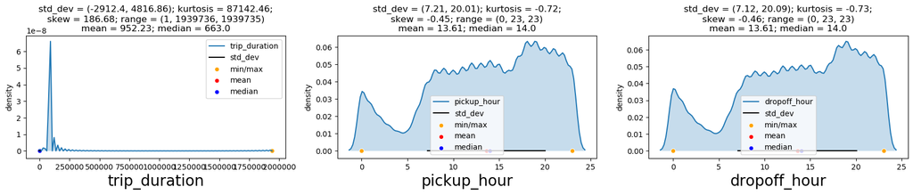

```python
UVA_numeric(df , numerical)
```

*Summary of numerical = trip_duration*

[output not shown]

*Summary of numerical - pickup_hour*

[output not shown]

*Summary of numerical - dropoff_hour*

[output not shown]

## Univariate analysis: Categorical

```python
# changing to category:

df['passenger_count'] = df['passenger_count'].astype('category')
df['pickup_month'] = df['pickup_month'].astype('category')
df['dropoff_month'] = df['dropoff_month'].astype('category')
```

```python
def UVA_category(df, var_group):

  '''
  Univariate_Analysis_categorical
  takes a group of variables (category) and plot/print all the value_counts and barplot.
  '''
  # setting figure_size
  size = len(var_group)
  plt.figure(figsize = (7*size,5), dpi = 100)

  # for every variable
  for j,i in enumerate(var_group):
    norm_count = df[i].value_counts(normalize = True)
    n_uni = df[i].nunique()

  #Plotting the variable with every information
    plt.subplot(1,size,j+1)
    sns.barplot(norm_count, norm_count.index , order = norm_count.index)
    plt.xlabel('fraction/percent', fontsize = 20)
    plt.ylabel('{}'.format(i), fontsize = 20)
    plt.title('n_uniques = {} \n value counts \n {};'.format(n_uni,norm_count))
```

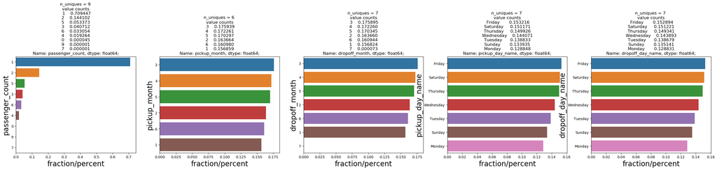

```python
UVA_category(df, categorical)
```

**Summary**

```python
df['pickup_time_bins'] = pd.cut(x = df['pickup_hour'], bins=[1,6,9,12,15,18,21,24])
df['pickup_time_bins'].value_counts(normalize = True)
```

```
(18, 21]    0.189466
(15, 18]    0.169552
(12, 15]    0.158684
(9, 12]     0.150133
(6, 9]      0.139518
(21, 24]    0.110283
(1, 6]      0.082364
Name: pickup_time_bins, dtype: float64
```

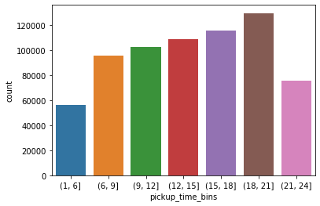

```python
sns.countplot(x = 'pickup_time_bins' , data = df)
```

```python
#converting 'store_and_fwd_flag' & 'vendor_id' to category

df['store_and_fwd_flag'] = df['store_and_fwd_flag'].astype('category')
df['vendor_id'] = df['vendor_id'].astype('category')
```

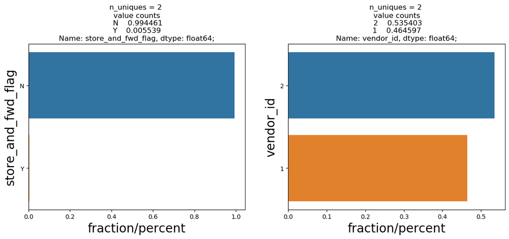

```python
UVA_category(df,['store_and_fwd_flag','vendor_id'])
```

**Summary**

- **Store_and_fwd_flag**
  - Majority of trips ~ 99.4% are "not a store and forward trip" which suggest connection during trip was robust .
- **vendor_id**:
  - There are two unique vendors, ride distribution seems competitive.
  - Distribution of rides between vendor 1 & 2 is 46.4 % and 53.5 % respectively.

NOTE - Longitude and Latitude analysis has been dropped conciously. Since they are specific geolocation on map(eg- a pickup latitude + a pickup longitude will give me one location), so they don't have specific individual significane.

This will be taken care post EDA.

*ENDING----------------UNIVARIATE------------- ANALYSIS*

## Bivariate Analysis (BVA)

**Hypothesis**

1. Does specific time of the day- hours have some relation with longer/Shorter trip_duration?
2. Do specific days of the week have any relation w.r.t. longer/Shorter trip_duration?

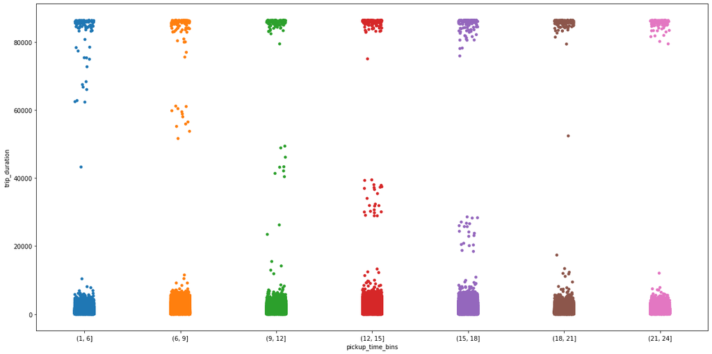

```python
# Does specific time of the day - hours have some relation with longer/shorter trip_duration?

plt.figure(figsize = (20,10))
sns.stripplot(x="pickup_time_bins", y="trip_duration",data=df)
plt.show()
```

*Summary*

```
* Distribution across all pickup_time_bins is similar,crowded at extremes at either less or more trip_duration. Less trip_duration being more popular among users.

* tip_duration across all time bins is either very high or less than 3hrs, this suggest there are ride
products made for booking cabs for more than a day or so.

* During daytime viz.1200hrs to 1500hrs and 1500hrs to 1800hrs trip_duration has greater distribution.

* Most rides are taken for less than 10000 sec ~ within 3hrs.
```

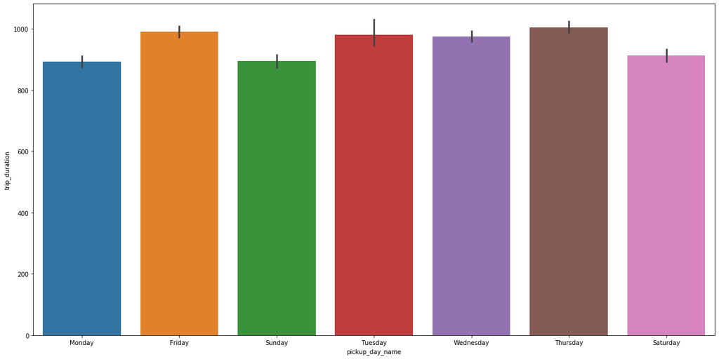

```python
# Do specific days of the week have any relation w.r.t. longer/Shorter trip_duration?


plt.figure(figsize = (20,10))
sns.barplot(x="pickup_day_name", y="trip_duration",data=df)
plt.show()
```

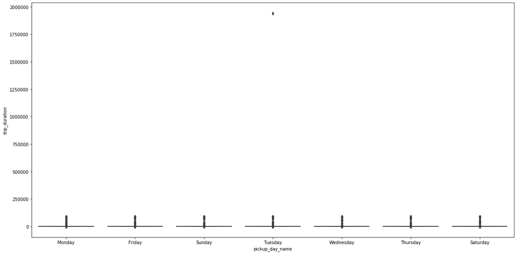

```python
plt.figure(figsize = (20,10))
sns.boxplot(x="pickup_day_name", y="trip_duration",data=df)
plt.show()
```

*Summary*

1. Average trip_duration is higher on Thursday and Friday than other days.
2. We see error bars at top of each bar which on plotting boxplot reveals Tueday's trip has extreme outliers.
3. Boxplot also reveals that most trip_durations among the data are concentrated below 10000 seconds or less than 3 hours.

# PUDO - PickUp and Drop Off

```python
pickup_map = df.head(1)
```

```python
import folium
```

```python
map_pu = folium.Map(location=[40.778873, -73.953918], zoom_start=10)

for (index, row) in pickup_map.iterrows():
    folium.Marker(location=[row.loc['pickup_latitude'], row.loc['pickup_longitude']],
                  tooltip='pU').add_to(map_pu)
map_pu
```

Make this Notebook Trusted to load map: File -> Trust Notebook

[interactive chart not shown]

```python
dropoff_map = df.head(1)
```

```python
map_Do = folium.Map(location=[40.771164, -73.963875], zoom_start=10)

for (index, row) in dropoff_map.iterrows():
    folium.Marker(location=[row.loc['dropoff_latitude'], row.loc['dropoff_longitude']],
                  tooltip='Do').add_to(map_Do)
map_Do
```

Make this Notebook Trusted to load map: File -> Trust Notebook

[interactive chart not shown]

*ENDING OF EDA*

# REAL TIME DATA ANALYTICS PROJECT